# Purchasing Power Parity: A Case Study

Jae H. Kim

03 March, 2023

# Introduction

The purchasing power parity is a fundamental relationship in international finance that the purchasing power for a homogeneous good in the two countries should be equal, at least in the long run: see Rogoff (1996). An interesting example is what is called the Big Mac index, developed by the economist magazine (https://www.economist.com/big-mac-index). It is based on the idea that the cost of a homogeneous good, such as a hamburger, should roughly equal between two countries, when exchange rate between the two currencies are taken into account. It is a concept that is satisfied under a range of conditions, such as no transaction costs or no trade barriers. Hence, it is a relationship that is believed to hold approximately or in the long run.

In this case study, the purchasing power parity (PPP) is empirically tested for Australia with respect to her two major trading partners: the United States (US) and New Zealand (NZ). The former is World’s biggest economy with its scale much bigger than that of Australian economy, while the latter is a much smaller economy but closely integrated with Australia economically, geographically and culturally. It is possible that such contrasting features can provide interesting insights as to the empirical validity of the PPP.

The quarterly real exchange rates from 1990 to 2021 (128 observations) are calculated from the nominal exchange rates and CPI figures, obtained from FRED (https://fred.stlouisfed.org/). Following Brooks (2019), the real exchange rate is defined as

$$\begin{equation}\label{eq1}
Q_t =\frac{E_t P_t^*}{P_t},
\end{equation}$$
where $E_t$ is the nominal exchange rate at time $t$, $P_t$ is the domestic price level, and $P_t^*$ is the foreign price level. The above expression can be linearized by transforming to the natural logarithm: i.e.,

$$\begin{equation}
Y_t = \log(E_t) + \log( P_t^*) - \log(P_t).
\end{equation}$$

# Econometric background

Let $Y_t \equiv \log(Q_t)$ be the log of real exchange rate at time $t$. A testable hypothesis for $Y_t$ in relation to the PPP is that $Y_t$ is a stationary time series. A stationary time series has a long-term (unconditional) mean and variance, which do not change over time. In addition, it has a dependence structure on its own past, which ensures that a deviation from the long-term mean is only temporary and transient. As a result, a stationary time series shows a mean-reverting pattern, where a shock to the time series has only a temporary effect over time. If $Y_t$ shows such a property, then it is a reflection that the PPP holds in the long run.

More formally, a stationary time series $Y_t$ should satisfy the following three conditions:

- $E(Y_t) = \mu$
- $Var(Y_t) = \sigma^2$
- $Cov(Y_t,Y_{t-s}) = \gamma_s$

where $\mu$ is the long-term mean, $\sigma^2$ is the long-term variance, and $\gamma_s$ is the auto-covariance of order $s$, all of which are time invariant. Note that $\gamma_s$ measures the degree of co-variation between the $Y_t$ and $Y_{t-s}$. We can also define auto-correlation $\rho_s =\frac{ \gamma_s}{\gamma_0}$, which is a unit-free measure of association between $Y_t$ and $Y_{t-s}$.

On the other hand, a class of time series shows a pattern different from a stationary time series. Typically, we pay attention to a time series called a unit-root process, which is non-stationary. That is, this class of time series violates at least one of the above three conditions. A simple well-known example is a random walk, which can be written as
$$\begin{equation}\label{eq3}
Y_t = Y_{t-1} + u_t,
\end{equation}$$
where $u_t$ is a stationary random error with zero mean and fixed variance $\sigma_u^2$. It can be shown that this time series has a time-varying variance and auto-covariance. That is,

- $E(Y_t) = 0$
- $Var(Y_t) = t \sigma_u^2$
- $Cov(Y_t,Y_{t-s}) = (t-s)\sigma_u^2$

As a result, a random walk (unit-root) time series shows a strong tendency to deviate further away from the long-term mean in response to a shock. In contrast to stationary time series, this time series show a pattern of mean-aversion, and a shock to the time series has a persistent effect over time.

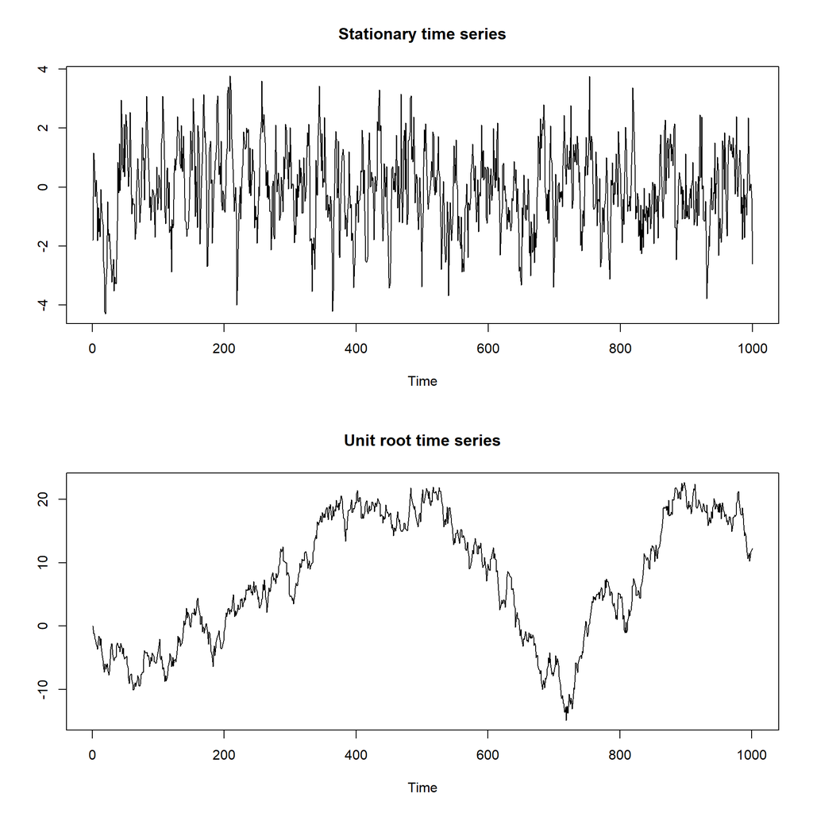

Stationary vs, non-stationary time series: Time plots

Figure 1 plots examples of stationary and non-stationary time series with a unit root. The stationary time series in the upper panel clearly shows a fluctuations around the mean of 0, with a fixed variability and clear mean-reversion. In contrast, the unit-root time series in the lower panel clearly shows a strong pattern of mean-aversion, and increasing variability over time.

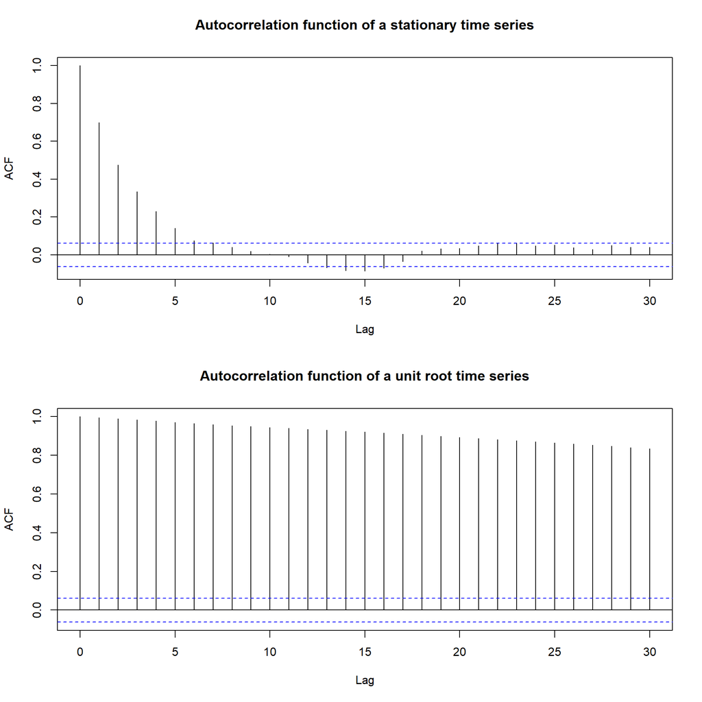

Stationary vs, non-stationary time series: Dependence Structure

Figure 2 presents auto-correlation functions (ACF) for stationary and unit root time series. The ACF plots the auto-correlation $\rho_s$ of a time series against $s$, and presents the degree of linear dependence of a time series in response to a shock. It can be seen that a stationary time series show responses over time which quickly disappears, while a unit root time series shows response which are persistent and permanent.

If a real exchange rate shows a time series pattern of a stationary time series, then it is evidence that the PPP holds in the long run. A real exchange rate showing the pattern of unit root time series is evidence that the PPP does not hold. On this basis, past empirical studies in the literature of the PPP have used what is called unit root testing as a means of testing for the empirical validity of the PPP.

# Descriptive Features of Real Exchange Rates

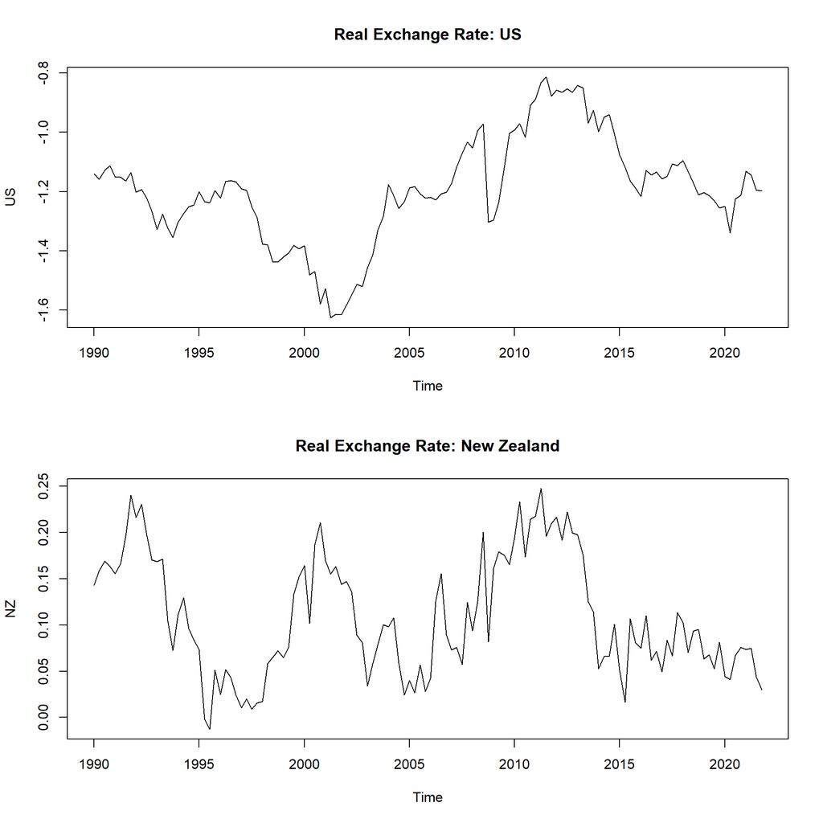

Time plots of Real Exchange Rates

Figure 3 plots the real exchange rates (in natural logarithm) for US and NZ against Australian dollar. The US rate looks much smoother, showing a degree of persistence; while the NZ rate shows a tendency of mean-reversion with much more frequent ups and downs. Similar features are evident from the auto-correlation functions (against years) reported in Figure 4, where the US rate shows a higher degree of persistence or dependence on its own past. The US rate takes nearly five years for the auto-correlation values to get to zero statistically, while the NZ rates takes only about two years for its auto-correlation values approach zero statistically.

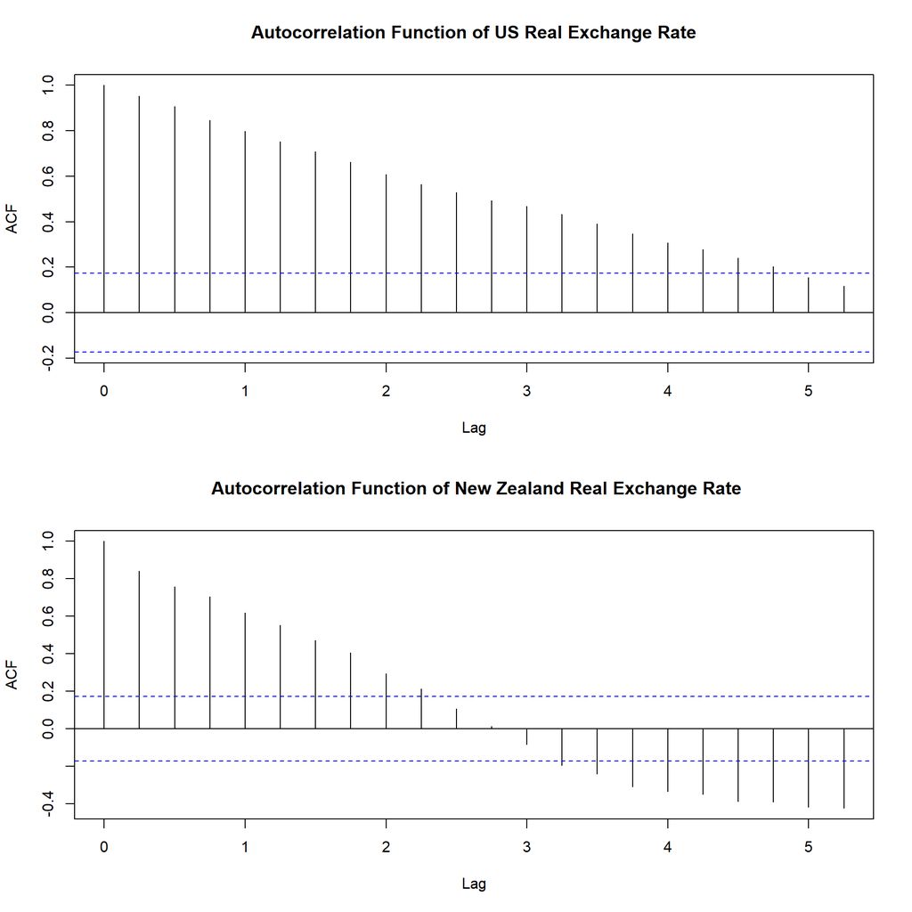

Auto-correlation functions of Real Exchange Rates

# Hypotheses

As discussed, the main hypothesis to be tested in this case study is whether the real exchange rate follows a unit root time series or stationary time series. As discussed above, the presence of a unit root in the real exchange rate is evidence against the validity of the PPP.

A unit root time series is often referred to as an integrated time series of order 1, denoted as $I(1)$, while a stationary time series is said to be an integrated time series of order 0, denoted as $I(0)$. Hence, the main hypothesis is written as

- $H_0: Y_t \sim I(1)$
- $H_1: Y_t \sim I(0)$

where $Y_t$ is the natural logarithm of the real exchange rate.

Given the characteristics of the New Zealand economy in relation to the Australian economy mentioned above, it is possible that the PPP is more likely to hold between Australia and New Zealand. This point will closely be examined when empirical results are discussed.

# Methodology

In this section, the main methodologies of testing for the PPP and measuring the degree of persistence from the deviation is presented. They include unit root tests and half-life estimation, which have been widely used in the context of testing for the PPP.

## Unit root testing

A unit root test is designed to test whether a time series is stationary or non-stationary with a unit root. The most popular is the augmented Dickey-Fuller (ADF) test proposed by Dickey and Fuller (1979). It is based on the following equation:

$$\begin{equation}
\Delta Y_t = \mu + \lambda Y_{t-1} + \sum_{j=1}^{m} \rho_j \Delta
Y_{t-j}+ e_t,
\end{equation}$$
where $e_t$ is a random error with zero mean and fixed variance, and $m$ is the order of augmentation and $\Delta Y_t \equiv Y_t - Y_{t-1}$. Under $H_0: \lambda = 0$, the time series $Y_t$ is non-stationary with a unit root, and under $H_1: \lambda< 0$, it is stationary. The test statistic is the usual one-tailed $t$-statistic for $\lambda$, denoted as $\tau_\mu$, which asymptotically follows a distribution tabulated by Dickey and Fuller (1979). Many econometric packages automatically report the $\tau_\mu$ statistic, accompanied by its critical values or $p$-values. The decision is to reject $H_0$ at the $\alpha$ level of significance if its $p$-value is less than $\alpha$ or the value of $\tau_\mu$ is less than its $\alpha$-level critical value.

A major problem of the ADF test is that it has a low statistical power or a high probability of Type II error, under the sample size widely used in practice. The level of significance $\alpha$ represents the probability of Type I error, which is the error of rejecting the true $H_0$. There is also an unavoidable error called Type II error, which is the error of failure to rejecting the false $H_0$, which is denoted as $\beta$. The power is defined as $1-\beta$, which is the probability of rejecting $H_0$ when it is false. A low power means a high probability of Type II error, which indicates that the researchers may often accept the null hypothesis of unit root when in fact the time series under investigation is stationary. When the researcher makes a decision as to the presence of a unit root, this point of low power should be taken into account. In response to the problem of low power of the ADF test, a number of more powerful tests have been proposed and adopted in the context of testing for the PPP. A notable test is the DF-GLS tests Elliott, Rothenberg, and Stock (1996).

## Half-life

To measure and compare the degree of mean-reversion from the deviation of the PPP, the half-life is estimated as a measure of persistence. It is defined, according to Rogoff (1996), as the number of periods required for a response to a shock to a time series dissipate by half. It has been widely adopted in the context of testing empirical validity of the the PPP: see Cheung and Lai (2000), Murray and Papell (2002), Kilian and Zha (2002), and J. Kim (2005). It is calculated using the following formula:

$$\begin{equation}
h = \frac{\log(0.5)}{\log(1+\lambda)}.
\end{equation}$$

Note that, in the event of unit root where $\lambda = 0$, $h = \infty$ indicating the property of mean-aversion. If $\lambda < 0$, the value of $h$ is finite and positive, indicative of mean-reversion to the PPP. The value of $h$ can be estimated using the least-squares (LS) estimator $\hat{\lambda}$ for $\lambda$. That is,

$$\begin{equation}\label{eq4}
\hat{h} = \frac{\log(0.5)}{\log(1+\hat{\lambda})}.
\end{equation}$$

The formula for the half-life given above is based on the following argument. Consider a simple case of stationary autoregressive model of order 1, which can be written as

$$Y_t = \mu + \rho Y_{t-1} + e_t$$
Equivalently, we can write
$$\Delta Y_t = \mu + \lambda Y_{t-1} + e_t,$$
where $\lambda \equiv \rho-1$. It is well-know that the model can be written as a moving average model of infinite order: see, for example, Hamilton (2020). That is,
$$Y_t = \mu + e_t + \rho e_{t-1}
+ \rho^2 e_{t-2} + \rho^3 e_{t-3} ....$$
This means that, in response to a unit shock at time $t-h$, the response of $Y_t$ is $\rho^h$. That is, to a unit shock that occurred $h$-period ago, the expected change of $Y$ is $\rho^h$. More formally, the value of impulse-response of $Y$ with respect to a unit shock $h$-period ago can be written as
$$\frac{\partial Y_t}{\partial
e_{t-h}} \equiv \frac{\partial Y_{t+h}}{\partial e_{t}} = \rho^h.$$
By definition, the half-life is the value of $h$ such that
$$\begin{equation}\label{eq5}
\rho^h = 0.5.
\end{equation}$$
Taking the natural logarithm of both side of the above and rearrange the terms for $h$, we have the expression as required, using the identity that $\rho = 1 + \lambda$: see, for details, Granger and Newbold (2014).

# Empirical results

In this section, the empirical results are presented with their economic interpretations and assessment. The results of the unit root tests are presented, followed by the results of half-life estimation with further discussions and implications.

## Unit root testing

For the real exchange rate for the US, the value of ADF test statistic ($\tau_\mu$) is found to be $-0.4932$ with the $p$-value of 0.7956. This mean that we cannot reject the null hypothesis of unit root at the 10% level of significance. For the NZ rate, the statistic is $-1.5804$ with the $p$-value of 0.1765: again the evidence is that we cannot reject the null hypothesis of unit root at the 10% level of significance.

## Half-life estimation

As for the half-life, $\hat{\lambda} = -0.001576$ is obtained for the US rate, which gives $\hat{h} = 440$. This means that the estimated value of half-life is 440 quarters, and that it takes 110 years for responses to a shock to the US rate becomes half. This is a clear evidence of mean-aversion, consistent with the presence of a unit root near unit root. On the other hand, for the NZ rate, $\hat{\lambda} = -0.02185$ and $\hat{h} = 31$, indicating a much shorter half-life of almost 7 years (31 quarters). That is, a shock to the NZ rate takes about 7 years to become half. This is evidence against the presence of a unit root, in support of the property of mean-reversion.

# Concluding remarks

# R code

The R code used is presented in this section. The data files in the form of Excel csv file should be placed in the working directory. The urca package of Pfaff (2008) available from the programming language R (R Core Team (2019)) should also be installed before this code is run.

```r
# Reading data and convert the series into quarterly frequency
AUS=read.csv("AUSCPI.csv",header = TRUE)
AUP = ts(AUS[,2], frequency=4,start=c(1960,1))

US=read.csv("USCPI.csv",header = TRUE)
USP = ts(US[,2], frequency=12,start=c(1947,1))

NZ=read.csv("NZCPI.csv",header = TRUE)
NZP = ts(NZ[,2], frequency=4,start=c(1960,1))

AUE=read.csv("AUSEX.csv",header = TRUE)
AU = ts(AUE[,2], frequency=12,start=c(1971,1))

NZE=read.csv("NZE.csv",header = TRUE)
NZ = ts(NZE[,2], frequency=12,start=c(1971,1))

index=seq(1,length(NZ),3)
NZQ=ts(NZ[index],freq=4,start=c(1971,1))
AUQ=ts(AU[index],freq=4,start=c(1971,1))

index=seq(1,length(USP),3)
USPQ=ts(USP[index],freq=4,start=c(1947,1))

# CPI data for
AUcpi = window(AUP, start=c(1971,1),end=c(2021,4))
UScpi = window(USPQ, start=c(1971,1),end=c(2021,4))
NZcpi = window(NZP, start=c(1971,1),end=c(2021,4))

# exchange rate data:
AU = window(AUQ, start=c(1971,1),end=c(2021,4))
NZ = window(NZQ, start=c(1971,1),end=c(2021,4))
e=AU/NZ

# Real exchange rates in log
RealUS = log(AU*AUcpi/UScpi)
RealNZ = log(e*AUcpi/NZcpi)

library(urca)
#ADF test
ADFUS=summary(ur.df(RealUS))
ADFNZ=summary(ur.df(RealNZ))

#DF-GLS test
DFGLSUS=summary(ur.ers(RealUS))
DFGLSNZ=summary(ur.ers(RealNZ))

# half-life calculation
h_us = log(0.5)/log(1+ADFUS@testreg$coefficients[1,1])
h_nz = log(0.5)/log(1+ADFNZ@testreg$coefficients[1,1])
```

# References

Brooks, Chris. 2019. *Introductory Econometrics for Finance*. 4th ed. Cambridge University Press. https://doi.org/10.1017/9781108524872.

Cheung, Yin-Wong, and Kon S Lai. 2000. “On the Purchasing Power Parity Puzzle.” *Journal of International Economics* 52 (2): 321–30.

Dickey, David A, and Wayne A Fuller. 1979. “Distribution of the Estimators for Autoregressive Time Series with a Unit Root.” *Journal of the American Statistical Association* 74 (366a): 427–31.

Elliott, Graham, Thomas J Rothenberg, and James H Stock. 1996. “Efficient Tests for an Autoregressive Unit Root.” *Econometrica*. [Wiley, Econometric Society].

Granger, Clive William John, and Paul Newbold. 2014. *Forecasting Economic Time Series*. Academic Press.

Hamilton, James Douglas. 2020. *Time Series Analysis*. Princeton university press.

Kilian, Lutz, and Tao Zha. 2002. “Quantifying the Uncertainty about the Half-Life of Deviations from Purchasing Power Parity.” *Journal of Applied Econometrics* 17 (2): 107–25.

Kim, Jae H, and In Choi. 2017. “Unit Roots in Economic and Financial Time Series: A Re-Evaluation at the Decision-Based Significance Levels.” *Econometrics* 5 (3): 41.

Kim, Jaebeom. 2005. “Convergence Rates to Purchasing Power Parity for Traded and Nontraded Goods: A Structural Error-Correction Model Approach.” *Journal of Business & Economic Statistics* 23 (1): 76–86.

Murray, Christian J, and David H Papell. 2002. “The Purchasing Power Parity Persistence Paradigm.” *Journal of International Economics* 56 (1): 1–19.

Pfaff, B. 2008. *Analysis of Integrated and Cointegrated Time Series with r*. Second. New York: Springer. http://www.pfaffikus.de.

R Core Team. 2019. *R: A Language and Environment for Statistical Computing*. Vienna, Austria: R Foundation for Statistical Computing. https://www.R-project.org/.

Rogoff, Kenneth. 1996. “The Purchasing Power Parity Puzzle.” *Journal of Economic Literature* 34 (2): 647–68.